# Maching learning project

Lisette

2/17/2017

## Coursera Practical Machine Learning Final Project

# The data for this project come from this source: http://groupware.les.inf.puc-rio.br/har.

First we name the test and training files “train_data” and “test_data.” And then we read in the data into two files named “training” and “test.”

# Read in files

```r
train_data<-"https://d396qusza40orc.cloudfront.net/predmachlearn/pml-training.csv"
test_data<-"https://d396qusza40orc.cloudfront.net/predmachlearn/pml-testing.csv"

training <-read.csv(train_data, na.strings=c("NA","#DIV/0!",""))
testing <-read.csv(test_data,na.strings=c("NA","#DIV/0!",""))
```

We are interested in predicting how the subject did the exercise “classe”. The train data set has 14718 rows and 160 columns. There are 5 classes of exercise sitting-down, standing-up, standing, walking, and sitting. Measeurments were collected on 8 hours of activities of 4 healthy subjects

Let’s partitian the training data into a training and test set from my training set

```r
set.seed(57)
inTrain = createDataPartition(training$classe, p = 3/4)[[1]]
train = training[ inTrain,]
test = training[-inTrain,]
```

Next, lets look at how many measurements there are in each classe in the training set.

```r
summary(train$classe)
```

```
##    A    B    C    D    E
## 4185 2848 2567 2412 2706
```

It looks like there is a lot of missing data. Let’s identify all the nonull fields and keep them in the train set

```r
nonull<- nearZeroVar(train, saveMetrics=TRUE)
train <- train[,nonull$nzv==FALSE]
```

Now that we now have 129 fields in the data set, which ones are there?

```r
names(train)
```

```
##   [1] "X"                        "user_name"
##   [3] "raw_timestamp_part_1"     "raw_timestamp_part_2"
##   [5] "cvtd_timestamp"           "num_window"
##   [7] "roll_belt"                "pitch_belt"
##   [9] "yaw_belt"                 "total_accel_belt"
##  [11] "kurtosis_roll_belt"       "kurtosis_picth_belt"
##  [13] "skewness_roll_belt"       "skewness_roll_belt.1"
##  [15] "max_roll_belt"            "max_picth_belt"
##  [17] "max_yaw_belt"             "min_roll_belt"
##  [19] "min_pitch_belt"           "min_yaw_belt"
##  [21] "amplitude_roll_belt"      "amplitude_pitch_belt"
##  [23] "var_total_accel_belt"     "avg_roll_belt"
##  [25] "stddev_roll_belt"         "var_roll_belt"
##  [27] "avg_pitch_belt"           "stddev_pitch_belt"
##  [29] "var_pitch_belt"           "avg_yaw_belt"
```

[output cut: 50 more lines]

We still have the field “X” which is just the index field, we should remove since it is not a measurement and may skew the results.

```r
train <-select(train, -X)
```

Now we have 128 fields in the dataset, but it looks like there are still quite a few fields with lots of nulls. Let’s remove all the fields with more than 60% NA values and create a clean training set

```r
train_clean <- train #creating another subset to iterate in loop
for(i in 1:length(train)) { #for every column in the training dataset
  if( sum( is.na( train[, i] ) ) /nrow(train) >= .6 ) { #if n?? NAs > 60% of total observations
    for(j in 1:length(train)) {
      if( length( grep(names(train[i]), names(train_clean)[j]) ) ==1)  { #if the columns are the same:
        train_clean <- train_clean[ , -j] #Remove that column
      }
    }
  }
}

dim(train_clean)
```

```
## [1] 14718    58
```

Now we have 58 variables including fields that only have less than 60% NA values. Let’s make sure that the testing data has the same fields.

```r
cleanfields<- colnames(train_clean)
cleanfields1<- colnames(train_clean[,-58])

test<-test[cleanfields]
testing<- testing[cleanfields1]
```

We also need to make sure the test and training data are the same type by coercing the testing dataset.

```r
for (i in 1:length(test) ) {
  for(j in 1:length(train_clean)) {
    if( length( grep(names(train_clean[i]), names(test)[j]) ) == 1)  {
      class(test[j]) <- class(train_clean[i])
    }
  }
}

testing <- rbind(train_clean[2, -58] , testing)
testing <- testing[-1,]
```

# Prediction Models

Let’s run 3 prediction models on training data using all the fields in the clean data; random forest, gradient boosting, and classification tree.

For each of these techniques, we will run the train function, the predict function and calculate the confusion matrix to get the accuracy.

# Random forests

```r
rf <- randomForest(classe ~. , data=train_clean )
pred_rf <- predict(rf, test)
confusionMatrix(pred_rf, test$classe)
```

```
## Confusion Matrix and Statistics
##
##           Reference
## Prediction    A    B    C    D    E
##          A 1395    0    0    0    0
##          B    0  949    1    0    0
##          C    0    0  853    2    0
##          D    0    0    1  802    0
##          E    0    0    0    0  901
##
## Overall Statistics
##
##                Accuracy : 0.9992
##                  95% CI : (0.9979, 0.9998)
##     No Information Rate : 0.2845
##     P-Value [Acc > NIR] : < 2.2e-16
##
##                   Kappa : 0.999
##  Mcnemar's Test P-Value : NA
##
## Statistics by Class:
##
##                      Class: A Class: B Class: C Class: D Class: E
## Sensitivity            1.0000   1.0000   0.9977   0.9975   1.0000
## Specificity            1.0000   0.9997   0.9995   0.9998   1.0000
## Pos Pred Value         1.0000   0.9989   0.9977   0.9988   1.0000
## Neg Pred Value         1.0000   1.0000   0.9995   0.9995   1.0000
## Prevalence             0.2845   0.1935   0.1743   0.1639   0.1837
## Detection Rate         0.2845   0.1935   0.1739   0.1635   0.1837
## Detection Prevalence   0.2845   0.1937   0.1743   0.1637   0.1837
## Balanced Accuracy      1.0000   0.9999   0.9986   0.9986   1.0000
```

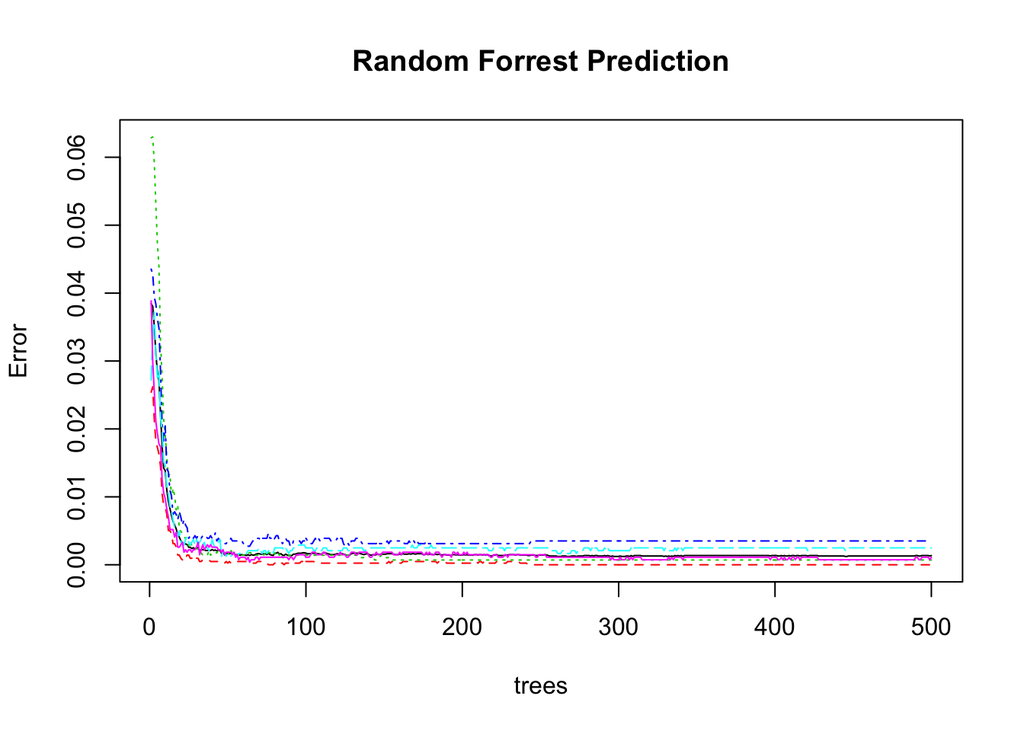

```r
plot(rf, main="Random Forrest Prediction")
```

##General Boosted Regression

```r
fitControl <- trainControl(method = "repeatedcv",
                           number = 5,
                           repeats = 1)

gbm <- train(classe ~ ., data=train_clean, method = "gbm",
                 trControl = fitControl,
                 verbose = FALSE)
pred_gbm <- predict(gbm, test)

confusionMatrix(pred_gbm, test$classe)
```

```
## Confusion Matrix and Statistics
##
##           Reference
## Prediction    A    B    C    D    E
##          A 1395    0    0    0    0
##          B    0  948    1    0    0
##          C    0    1  846    5    0
##          D    0    0    8  798    4
##          E    0    0    0    1  897
##
## Overall Statistics
##
##                Accuracy : 0.9959
##                  95% CI : (0.9937, 0.9975)
##     No Information Rate : 0.2845
##     P-Value [Acc > NIR] : < 2.2e-16
##
##                   Kappa : 0.9948
##  Mcnemar's Test P-Value : NA
##
## Statistics by Class:
##
##                      Class: A Class: B Class: C Class: D Class: E
## Sensitivity            1.0000   0.9989   0.9895   0.9925   0.9956
## Specificity            1.0000   0.9997   0.9985   0.9971   0.9998
## Pos Pred Value         1.0000   0.9989   0.9930   0.9852   0.9989
## Neg Pred Value         1.0000   0.9997   0.9978   0.9985   0.9990
## Prevalence             0.2845   0.1935   0.1743   0.1639   0.1837
## Detection Rate         0.2845   0.1933   0.1725   0.1627   0.1829
## Detection Prevalence   0.2845   0.1935   0.1737   0.1652   0.1831
## Balanced Accuracy      1.0000   0.9993   0.9940   0.9948   0.9977
```

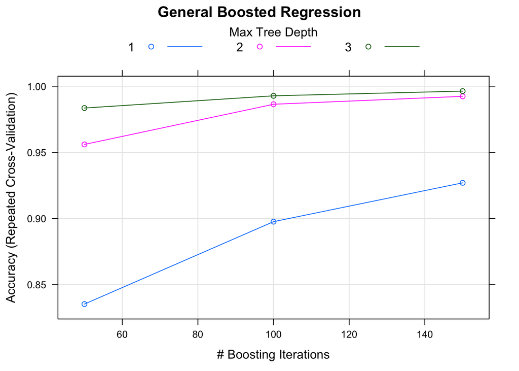

```r
plot(gbm, main="General Boosted Regression")
```

# Classification tree

```r
class_tree <- train(classe ~ ., data=train_clean, method = "rpart")
pred_ct <- predict(class_tree, test)

confusionMatrix(pred_ct, test$classe)
```

```
## Confusion Matrix and Statistics
##
##           Reference
## Prediction    A    B    C    D    E
##          A 1047  244   24   37   13
##          B   96  389   12    0    0
##          C   71  156  471   22   38
##          D  157  160  348  745  434
##          E   24    0    0    0  416
##
## Overall Statistics
##
##                Accuracy : 0.6256
##                  95% CI : (0.6119, 0.6392)
##     No Information Rate : 0.2845
##     P-Value [Acc > NIR] : < 2.2e-16
##
##                   Kappa : 0.5297
##  Mcnemar's Test P-Value : NA
##
## Statistics by Class:
##
##                      Class: A Class: B Class: C Class: D Class: E
## Sensitivity            0.7505  0.40991  0.55088   0.9266  0.46171
## Specificity            0.9094  0.97269  0.92912   0.7320  0.99400
## Pos Pred Value         0.7670  0.78270  0.62137   0.4040  0.94545
## Neg Pred Value         0.9017  0.87293  0.90738   0.9807  0.89135
## Prevalence             0.2845  0.19352  0.17435   0.1639  0.18373
## Detection Rate         0.2135  0.07932  0.09604   0.1519  0.08483
## Detection Prevalence   0.2783  0.10135  0.15457   0.3760  0.08972
## Balanced Accuracy      0.8300  0.69130  0.74000   0.8293  0.72786
```

[figure not shown]

```r
fancyRpartPlot(class_tree$finalModel)
```

# Combine the models to see if we get something better

Now that we have run each of these 3 techniques individually, lets combine them to see if we get a better prediction model.

```r
pred_all<- data.frame( pred_rf, pred_gbm, pred_ct, classe= test$classe)
combModFit <- train(classe ~., method="rf", data=pred_all)
combPred <- predict(combModFit, pred_all)

#combined accuracy
confusionMatrix(combPred, test$classe)$overall[1]
```

```
##  Accuracy
## 0.9991843
```

# Predicting results on the testing data

```r
prediction_final <- predict( rf, newdata=testing, type = "class")
prediction_final
```

```
##  1 21  3  4  5  6  7  8  9 10 11 12 13 14 15 16 17 18 19 20
##  B  A  B  A  A  E  D  B  A  A  B  C  B  A  E  E  A  B  B  B
## Levels: A B C D E
```